# Bayesian GLM Part4

**More diagnostics**

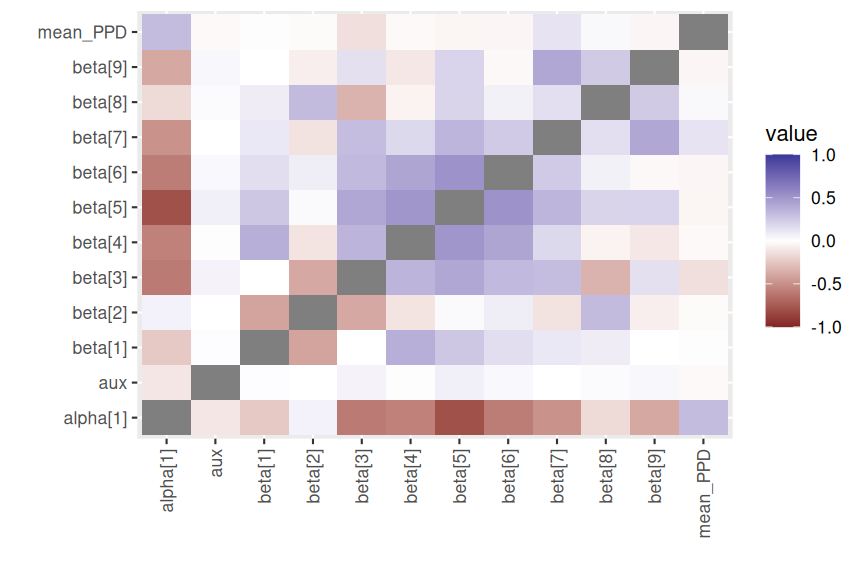

```r
ggs_crosscorrelation(loyn_ggs)
```

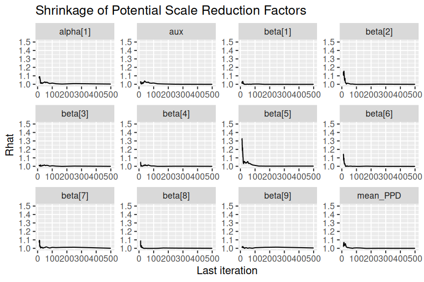

```r
ggs_grb(loyn_ggs)
```

**brm**

**bayesplot**

The `bayesplot` package offers a range of MCMC diagnostics as well as Posterior Probability Checks (PPC), all of which have a convenient `plot()` interface. Lets start with the MCMC diagnostics.

**See list of available diagnostics by name**

```r
available_mcmc()
```

```
bayesplot MCMC module:
  mcmc_acf
  mcmc_acf_bar
  mcmc_areas
  mcmc_areas_ridges
  mcmc_combo
  mcmc_dens
  mcmc_dens_chains
  mcmc_dens_overlay
  mcmc_hex
  mcmc_hist
  mcmc_hist_by_chain
  mcmc_intervals
  mcmc_neff
  mcmc_neff_hist
  mcmc_nuts_acceptance
  mcmc_nuts_divergence
  mcmc_nuts_energy
  mcmc_nuts_stepsize
  mcmc_nuts_treedepth
  mcmc_pairs
  mcmc_parcoord
  mcmc_rank_ecdf
  mcmc_rank_hist
  mcmc_rank_overlay
  mcmc_recover_hist
  mcmc_recover_intervals
  mcmc_recover_scatter
  mcmc_rhat
  mcmc_rhat_hist
  mcmc_scatter
  mcmc_trace
  mcmc_trace_highlight
  mcmc_violin
```

Of these, we will focus on:

- mcmc_trace: this plots the estimates of each parameter over the post-warmup length of each MCMC chain. Each chain is plotted in a different shade of blue, with each parameter in its own facet. Ideally, each **trace** should just look like noise without any discernible drift and each of the traces for a specific parameter should look the same (i.e, should not be displaced above or below any other trace for that parameter).

```
No divergences to plot.
```

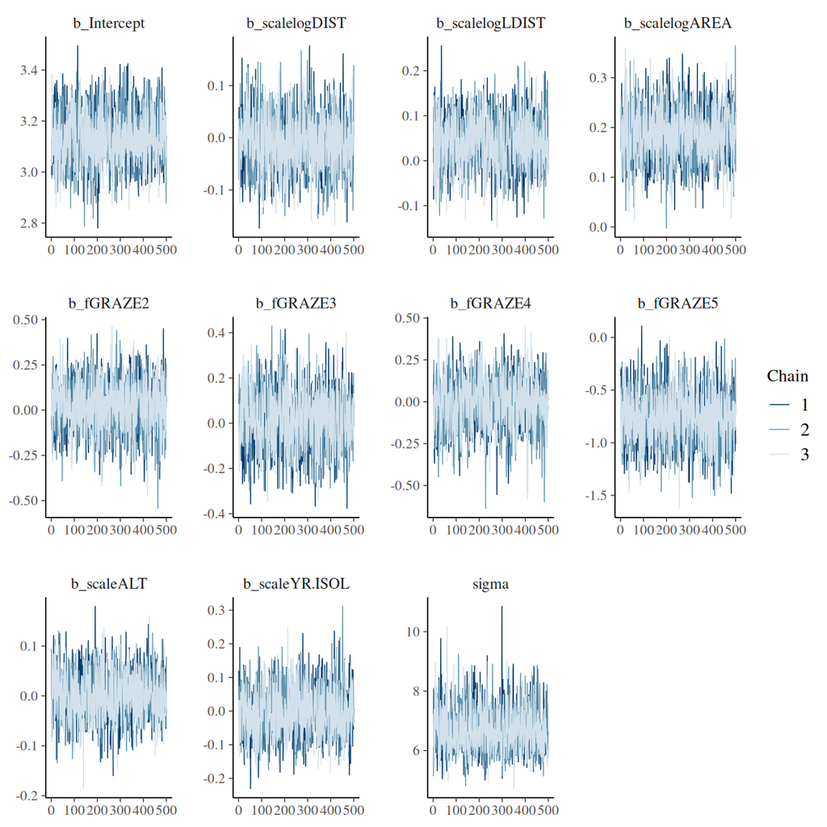

```r
loyn_brm3 |> mcmc_plot(type = "trace")
```

The chains appear well mixed and very similar

- acf (autocorrelation function): plots the autocorrelation between successive MCMC sample lags for each parameter and each chain

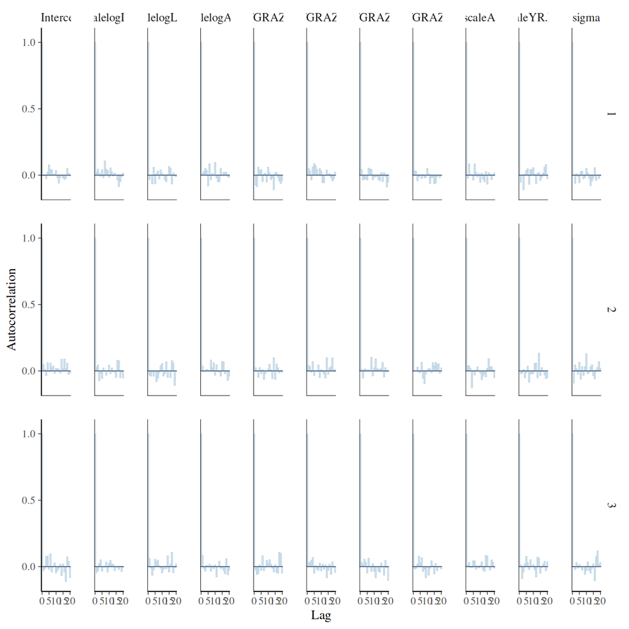

```r
loyn_brm3 |> mcmc_plot(type = "acf_bar")
```

There is no evidence of autocorrelation in the MCMC samples

- Rhat: Rhat is a measure of convergence between the chains. The closer the values are to 1, the more the chains have converged. Values greater than 1.05 indicate a lack of convergence. There will be an Rhat value for each parameter estimated.

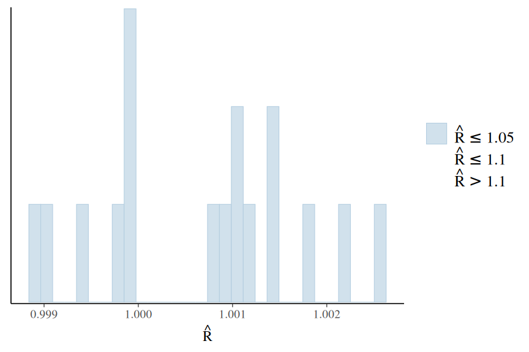

```r
loyn_brm3 |> mcmc_plot(type = "rhat_hist")
```

All Rhat values are below 1.05, suggesting the chains have converged.

- neff (number of effective samples): the ratio of the number of effective samples (those not rejected by the sampler) to the number of samples provides an indication of the effectiveness (and efficiency) of the MCMC sampler. Ratios that are less than 0.5 for a parameter suggest that the sampler spent considerable time in difficult areas of the sampling domain and rejected more than half of the samples (replacing them with the previous effective sample).

  If the ratios are low, tightening the priors may help.

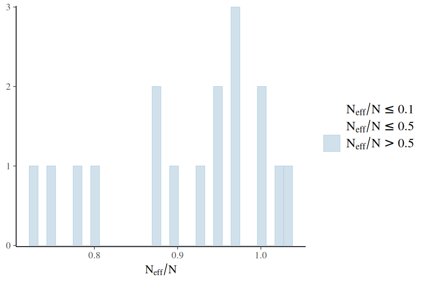

```r
loyn_brm3 |> mcmc_plot(type = "neff_hist")
```

Ratios all very high.

**More diagnostics**

[figure not shown]

```r
loyn_brm3 |> mcmc_plot(type = "combo")
```

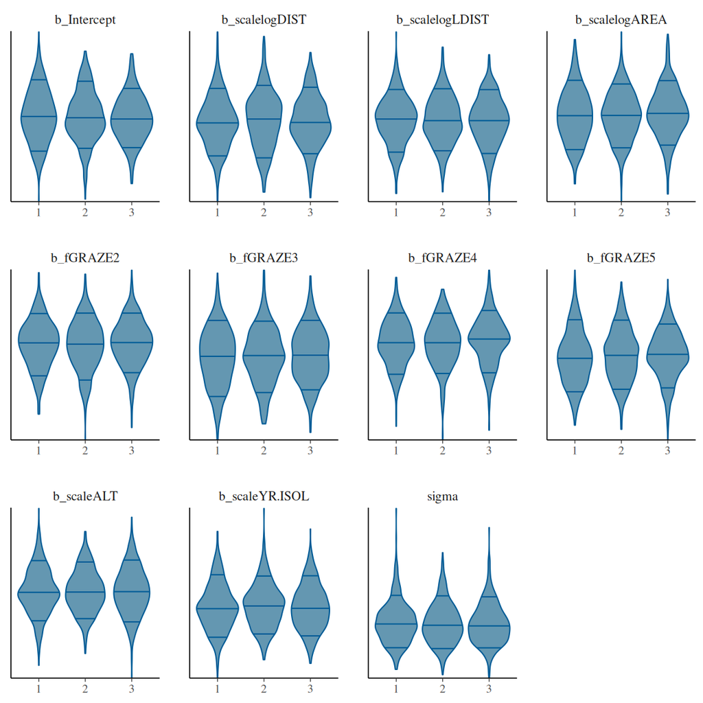

```r
loyn_brm3 |> mcmc_plot(type = "violin")
```

**stan plots**

The `rstan` package offers a range of MCMC diagnostics. Lets start with the MCMC diagnostics.

Of these, we will focus on:

- stan_trace: this plots the estimates of each parameter over the post-warmup length of each MCMC chain. Each chain is plotted in a different colour, with each parameter in its own facet. Ideally, each **trace** should just look like noise without any discernible drift and each of the traces for a specific parameter should look the same (i.e, should not be displaced above or below any other trace for that parameter).

```
'pars' not specified. Showing first 10 parameters by default.
```

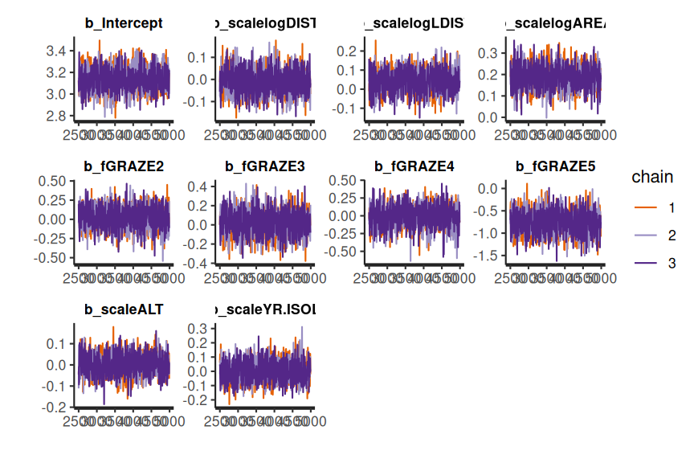

```r
loyn_brm3$fit |> stan_trace()
```

The chains appear well mixed and very similar

- stan_acf (autocorrelation function): plots the autocorrelation between successive MCMC sample lags for each parameter and each chain

```
'pars' not specified. Showing first 10 parameters by default.
```

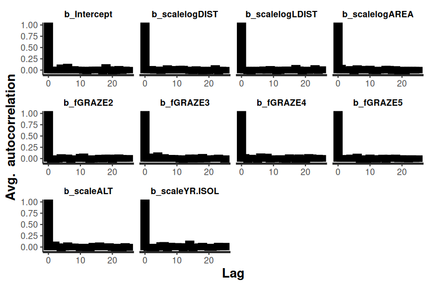

```r
loyn_brm3$fit |> stan_ac()
```

There is no evidence of autocorrelation in the MCMC samples

- stan_rhat: Rhat is a **scale reduction factor** measure of convergence between the chains. The closer the values are to 1, the more the chains have converged. Values greater than 1.05 indicate a lack of convergence. There will be an Rhat value for each parameter estimated.

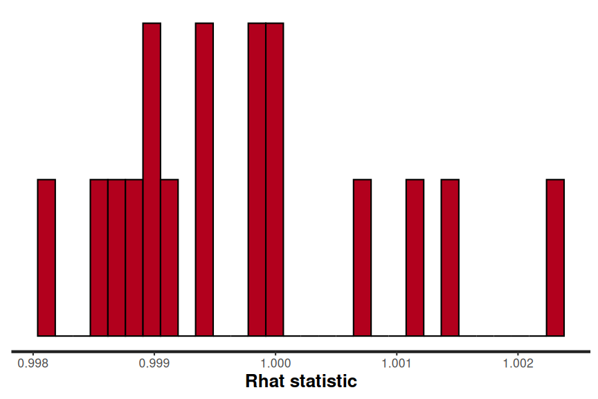

```r
loyn_brm3$fit |> stan_rhat()
```

All Rhat values are below 1.05, suggesting the chains have converged.

- stan_ess (number of effective samples): the ratio of the number of effective samples (those not rejected by the sampler) to the number of samples provides an indication of the effectiveness (and efficiency) of the MCMC sampler. Ratios that are less than 0.5 for a parameter suggest that the sampler spent considerable time in difficult areas of the sampling domain and rejected more than half of the samples (replacing them with the previous effective sample).

  If the ratios are low, tightening the priors may help.

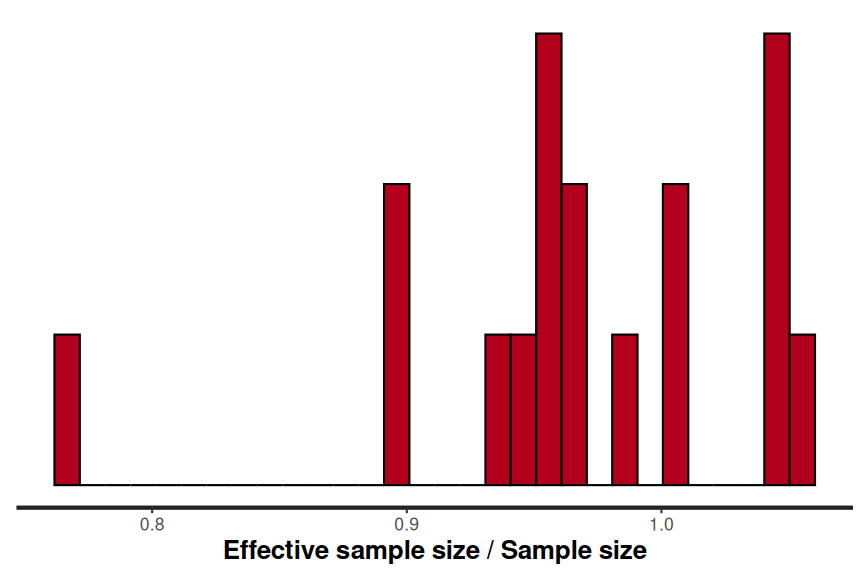

```r
loyn_brm3$fit |> stan_ess()
```

Ratios all very high.

```
'pars' not specified. Showing first 10 parameters by default.
```

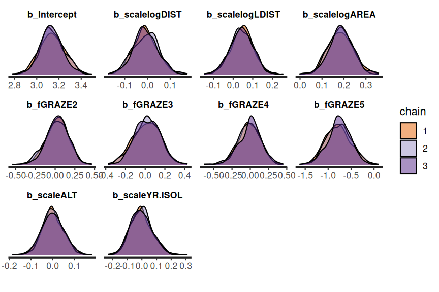

```r
loyn_brm3$fit |> stan_dens(separate_chains = TRUE)
```

**ggmcmc**

The `ggmean` package also has a set of MCMC diagnostic functions. Lets start with the MCMC diagnostics.

Of these, we will focus on:

- ggs_traceplot: this plots the estimates of each parameter over the post-warmup length of each MCMC chain. Each chain is plotted in a different colour, with each parameter in its own facet. Ideally, each **trace** should just look like noise without any discernible drift and each of the traces for a specific parameter should look the same (i.e, should not be displaced above or below any other trace for that parameter).

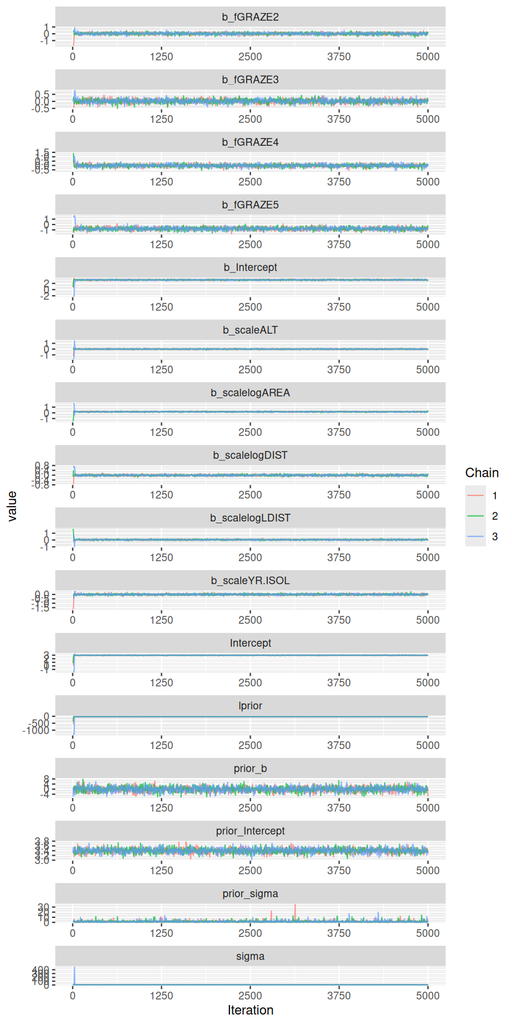

```r
loyn_ggs <- loyn_brm3 |> ggs(inc_warmup = FALSE, burnin = FALSE)
loyn_ggs |> ggs_traceplot()
```